```python
import pandas as pd
import numpy as np
import seaborn as sns
import matplotlib.pyplot as plt
```

```python
from google.colab import drive
drive.mount("/content/drive/")
```

```python
data = pd.read_csv("/content/drive/MyDrive/SuperKart.csv")
```

# **Exploring the Dataset**

```python
data
```

|  | Product_Id | Product_Weight | Product_Sugar_Content | Product_Allocated_Area | Product_Type | Product_MRP | Store_Id | Store_Establishment_Year | Store_Size | Store_Location_City_Type | Store_Type | Product_Store_Sales_Total |
| --- | --- | --- | --- | --- | --- | --- | --- | --- | --- | --- | --- | --- |
| 0 | FD6114 | 12.66 | Low Sugar | 0.027 | Frozen Foods | 117.08 | OUT004 | 2009 | Medium | Tier 2 | Supermarket Type2 | 2842.40 |
| 1 | FD7839 | 16.54 | Low Sugar | 0.144 | Dairy | 171.43 | OUT003 | 1999 | Medium | Tier 1 | Departmental Store | 4830.02 |
| 2 | FD5075 | 14.28 | Regular | 0.031 | Canned | 162.08 | OUT001 | 1987 | High | Tier 2 | Supermarket Type1 | 4130.16 |
| 3 | FD8233 | 12.10 | Low Sugar | 0.112 | Baking Goods | 186.31 | OUT001 | 1987 | High | Tier 2 | Supermarket Type1 | 4132.18 |
| 4 | NC1180 | 9.57 | No Sugar | 0.010 | Health and Hygiene | 123.67 | OUT002 | 1998 | Small | Tier 3 | Food Mart | 2279.36 |
| ... | ... | ... | ... | ... | ... | ... | ... | ... | ... | ... | ... | ... |
| 8758 | NC7546 | 14.80 | No Sugar | 0.016 | Health and Hygiene | 140.53 | OUT004 | 2009 | Medium | Tier 2 | Supermarket Type2 | 3806.53 |
| 8759 | NC584 | 14.06 | No Sugar | 0.142 | Household | 144.51 | OUT004 | 2009 | Medium | Tier 2 | Supermarket Type2 | 5020.74 |
| 8760 | NC2471 | 13.48 | No Sugar | 0.017 | Health and Hygiene | 88.58 | OUT001 | 1987 | High | Tier 2 | Supermarket Type1 | 2443.42 |
| 8761 | NC7187 | 13.89 | No Sugar | 0.193 | Household | 168.44 | OUT001 | 1987 | High | Tier 2 | Supermarket Type1 | 4171.82 |
| 8762 | FD306 | 14.73 | Low Sugar | 0.177 | Snack Foods | 224.93 | OUT002 | 1998 | Small | Tier 3 | Food Mart | 2186.08 |

8763 rows × 12 columns

```python
data.head()
```

|  | Product_Id | Product_Weight | Product_Sugar_Content | Product_Allocated_Area | Product_Type | Product_MRP | Store_Id | Store_Establishment_Year | Store_Size | Store_Location_City_Type | Store_Type | Product_Store_Sales_Total |
| --- | --- | --- | --- | --- | --- | --- | --- | --- | --- | --- | --- | --- |
| 0 | FD6114 | 12.66 | Low Sugar | 0.027 | Frozen Foods | 117.08 | OUT004 | 2009 | Medium | Tier 2 | Supermarket Type2 | 2842.40 |
| 1 | FD7839 | 16.54 | Low Sugar | 0.144 | Dairy | 171.43 | OUT003 | 1999 | Medium | Tier 1 | Departmental Store | 4830.02 |
| 2 | FD5075 | 14.28 | Regular | 0.031 | Canned | 162.08 | OUT001 | 1987 | High | Tier 2 | Supermarket Type1 | 4130.16 |
| 3 | FD8233 | 12.10 | Low Sugar | 0.112 | Baking Goods | 186.31 | OUT001 | 1987 | High | Tier 2 | Supermarket Type1 | 4132.18 |
| 4 | NC1180 | 9.57 | No Sugar | 0.010 | Health and Hygiene | 123.67 | OUT002 | 1998 | Small | Tier 3 | Food Mart | 2279.36 |

**statistics for numerical columns**

```python
data.info()
```

```
<class 'pandas.core.frame.DataFrame'>
RangeIndex: 8763 entries, 0 to 8762
Data columns (total 12 columns):
 #   Column                     Non-Null Count  Dtype
---  ------                     --------------  -----
 0   Product_Id                 8763 non-null   object
 1   Product_Weight             8763 non-null   float64
 2   Product_Sugar_Content      8763 non-null   object
 3   Product_Allocated_Area     8763 non-null   float64
 4   Product_Type               8763 non-null   object
 5   Product_MRP                8763 non-null   float64
 6   Store_Id                   8763 non-null   object
 7   Store_Establishment_Year   8763 non-null   int64
 8   Store_Size                 8763 non-null   object
 9   Store_Location_City_Type   8763 non-null   object
 10  Store_Type                 8763 non-null   object
 11  Product_Store_Sales_Total  8763 non-null   float64
dtypes: float64(4), int64(1), object(7)
memory usage: 821.7+ KB
```

```python
data.describe()
```

|  | Product_Weight | Product_Allocated_Area | Product_MRP | Store_Establishment_Year | Product_Store_Sales_Total |
| --- | --- | --- | --- | --- | --- |
| count | 8763.000000 | 8763.000000 | 8763.000000 | 8763.000000 | 8763.000000 |
| mean | 12.653792 | 0.068786 | 147.032539 | 2002.032751 | 3464.003640 |
| std | 2.217320 | 0.048204 | 30.694110 | 8.388381 | 1065.630494 |
| min | 4.000000 | 0.004000 | 31.000000 | 1987.000000 | 33.000000 |
| 25% | 11.150000 | 0.031000 | 126.160000 | 1998.000000 | 2761.715000 |
| 50% | 12.660000 | 0.056000 | 146.740000 | 2009.000000 | 3452.340000 |
| 75% | 14.180000 | 0.096000 | 167.585000 | 2009.000000 | 4145.165000 |
| max | 22.000000 | 0.298000 | 266.000000 | 2009.000000 | 8000.000000 |

```python
data.nunique()
```

```
Product_Id                   8763
Product_Weight               1113
Product_Sugar_Content           4
Product_Allocated_Area        228
Product_Type                   16
Product_MRP                  6100
Store_Id                        4
Store_Establishment_Year        4
Store_Size                      3
Store_Location_City_Type        3
Store_Type                      4
Product_Store_Sales_Total    8668
dtype: int64
```

```python
data.isnull().sum()
```

```
Product_Id                   0
Product_Weight               0
Product_Sugar_Content        0
Product_Allocated_Area       0
Product_Type                 0
Product_MRP                  0
Store_Id                     0
Store_Establishment_Year     0
Store_Size                   0
Store_Location_City_Type     0
Store_Type                   0
Product_Store_Sales_Total    0
dtype: int64
```

# **Definition of the Problem**

The objective is to forecast the sales income of various SuperKart locations in the future using past sales information as well as diverse product and store characteristics.

# Univariate Analysis

examining every variable separately.

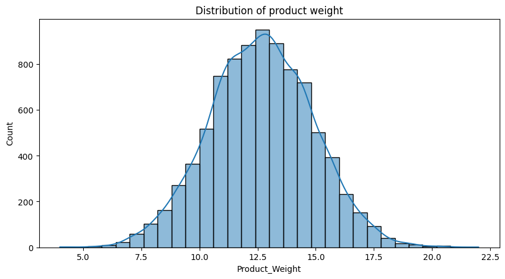

```python
plt.figure(figsize=(10, 5))
sns.histplot(data['Product_Weight'], bins=30, kde=True)
plt.title('Distribution of product weight')
plt.show()
```

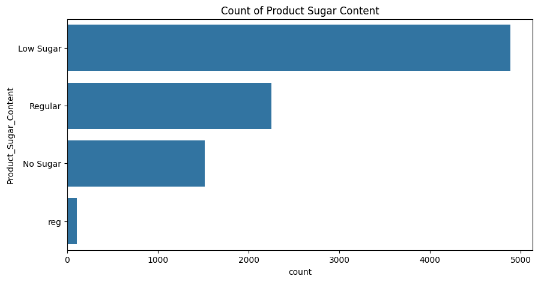

```python
plt.figure(figsize=(10, 5))
sns.countplot(data['Product_Sugar_Content'])
plt.title('Count of Product Sugar Content')
plt.show()
```

**Bivariate Analysis**

Investigating the connections between different variables

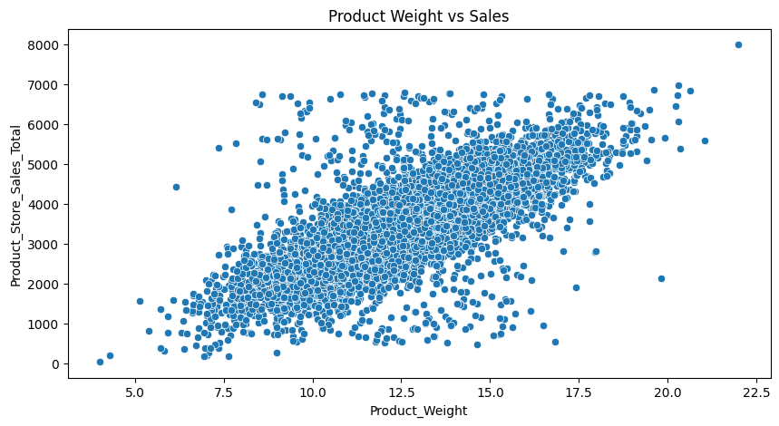

```python
plt.figure(figsize=(10, 5))
sns.scatterplot(x='Product_Weight', y='Product_Store_Sales_Total', data=data)
plt.title('Product Weight vs Sales')
plt.show()
```

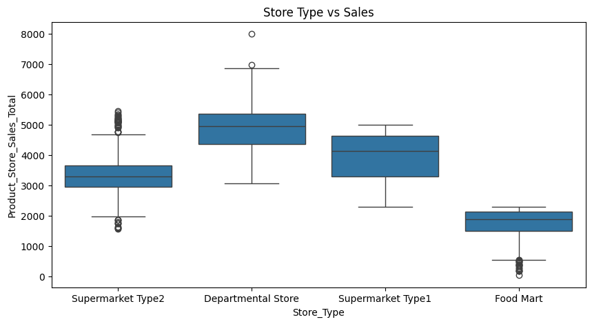

```python
plt.figure(figsize=(10, 5))
sns.boxplot(x='Store_Type', y='Product_Store_Sales_Total', data=data)
plt.title('Store Type vs Sales')
plt.show()
```

```python
data[data.duplicated()]
```

|  | Product_Id | Product_Weight | Product_Sugar_Content | Product_Allocated_Area | Product_Type | Product_MRP | Store_Id | Store_Establishment_Year | Store_Size | Store_Location_City_Type | Store_Type | Product_Store_Sales_Total |
| --- | --- | --- | --- | --- | --- | --- | --- | --- | --- | --- | --- | --- |

```python
data['Product_Weight'].fillna(data['Product_Weight'].mean(), inplace=True)

# Convert categorical variables to numerical using one-hot encoding
data = pd.get_dummies(data, columns=['Product_Sugar_Content', 'Product_Type', 'Store_Size', 'Store_Location_City_Type', 'Store_Type'], drop_first=True)
```

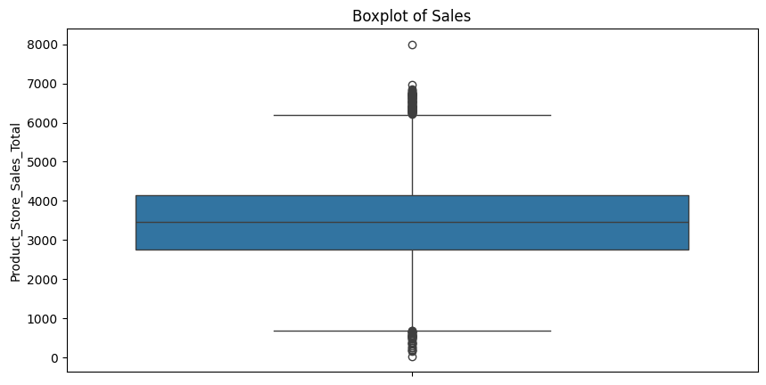

```python
# Check for outliers using boxplot
plt.figure(figsize=(10, 5))
sns.boxplot(data['Product_Store_Sales_Total'])
plt.title('Boxplot of Sales')
plt.show()
```

```python
# Removing outliers - assuming values beyond the 95th percentile are outliers
q95 = data['Product_Store_Sales_Total'].quantile(0.95)
data = data[data['Product_Store_Sales_Total'] < q95]
```

```python
# Prepare data for modeling
X = data.drop(columns=['Product_Id', 'Store_Id', 'Product_Store_Sales_Total'])
y = data['Product_Store_Sales_Total']
```

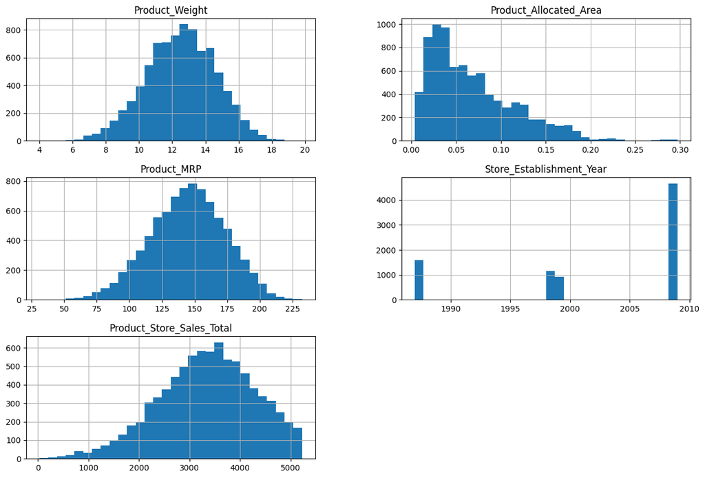

```python
data.hist(bins=30, figsize=(15, 10))
plt.show()
```

```python
sns.pairplot(data)
```

[figure not shown]

**Building a Model - Bagging**

Building a Bagging Regressor, Random Forest, and Decision Tree.

```python
from sklearn.model_selection import train_test_split
from sklearn.tree import DecisionTreeRegressor
from sklearn.ensemble import RandomForestRegressor, BaggingRegressor
from sklearn.metrics import mean_squared_error
```

```python
# Spliting the data into training and testing sets
X_train, X_test, y_train, y_test = train_test_split(X, y, test_size=0.2, random_state=42)
```

```python
# Decision Tree Regressor
dt = DecisionTreeRegressor(random_state=42)
dt.fit(X_train, y_train)
y_pred_dt = dt.predict(X_test)
print(f'Decision Tree RMSE: {np.sqrt(mean_squared_error(y_test, y_pred_dt))}')
```

```
Decision Tree RMSE: 342.2206276274031
```

```python
# Random Forest Regressor
rf = RandomForestRegressor(random_state=42)
rf.fit(X_train, y_train)
y_pred_rf = rf.predict(X_test)
print(f'Random Forest RMSE: {np.sqrt(mean_squared_error(y_test, y_pred_rf))}')
```

```
Random Forest RMSE: 266.7190559552652
```

```python
# Bagging Regressor
br = BaggingRegressor(random_state=42)
br.fit(X_train, y_train)
y_pred_br = br.predict(X_test)
print(f'Bagging Regressor RMSE: {np.sqrt(mean_squared_error(y_test, y_pred_br))}')
```

```
Bagging Regressor RMSE: 277.68996437530353
```

```python
from sklearn.model_selection import GridSearchCV
```

```python
# Hyperparameter tuning for Decision Tree
param_grid_dt = {'max_depth': [5, 10, 15], 'min_samples_split': [2, 5, 10]}
grid_dt = GridSearchCV(DecisionTreeRegressor(random_state=42), param_grid_dt, cv=5, scoring='neg_mean_squared_error')
grid_dt.fit(X_train, y_train)
best_dt = grid_dt.best_estimator_
y_pred_best_dt = best_dt.predict(X_test)
print(f'Tuned Decision Tree RMSE: {np.sqrt(mean_squared_error(y_test, y_pred_best_dt))}')
```

```
Tuned Decision Tree RMSE: 308.3897435716996
```

```python
# Hyperparameter tuning for Random Forest
param_grid_rf = {'n_estimators': [100, 200], 'max_depth': [5, 10, 15]}
grid_rf = GridSearchCV(RandomForestRegressor(random_state=42), param_grid_rf, cv=5, scoring='neg_mean_squared_error')
grid_rf.fit(X_train, y_train)
best_rf = grid_rf.best_estimator_
y_pred_best_rf = best_rf.predict(X_test)
print(f'Tuned Random Forest RMSE: {np.sqrt(mean_squared_error(y_test, y_pred_best_rf))}')
```

```
Tuned Random Forest RMSE: 263.2550528095984
```

```python
# Hyperparameter tuning for Bagging Regressor
param_grid_br = {'n_estimators': [10, 50, 100]}
grid_br = GridSearchCV(BaggingRegressor(random_state=42), param_grid_br, cv=5, scoring='neg_mean_squared_error')
grid_br.fit(X_train, y_train)
best_br = grid_br.best_estimator_
y_pred_best_br = best_br.predict(X_test)
print(f'Tuned Bagging Regressor RMSE: {np.sqrt(mean_squared_error(y_test, y_pred_best_br))}')
```

```
Tuned Bagging Regressor RMSE: 266.76698946078125
```

```python
from sklearn.ensemble import AdaBoostRegressor, GradientBoostingRegressor
```

```python
# AdaBoost Regressor
ada = AdaBoostRegressor(random_state=42)
ada.fit(X_train, y_train)
y_pred_ada = ada.predict(X_test)
print(f'AdaBoost RMSE: {np.sqrt(mean_squared_error(y_test, y_pred_ada))}')
```

```
AdaBoost RMSE: 411.1433860728009
```

```python
# Gradient Boosting Regressor
gbr = GradientBoostingRegressor(random_state=42)
gbr.fit(X_train, y_train)
y_pred_gbr = gbr.predict(X_test)
print(f'Gradient Boosting RMSE: {np.sqrt(mean_squared_error(y_test, y_pred_gbr))}')
```

```
Gradient Boosting RMSE: 280.2287608415815
```

```python
# Hyperparameter tuning for AdaBoost
param_grid_ada = {'n_estimators': [50, 100, 200], 'learning_rate': [0.01, 0.1, 1.0]}
grid_ada = GridSearchCV(AdaBoostRegressor(random_state=42), param_grid_ada, cv=5, scoring='neg_mean_squared_error')
grid_ada.fit(X_train, y_train)
best_ada = grid_ada.best_estimator_
y_pred_best_ada = best_ada.predict(X_test)
print(f'Tuned AdaBoost RMSE: {np.sqrt(mean_squared_error(y_test, y_pred_best_ada))}')
```

```
Tuned AdaBoost RMSE: 393.7022831543543
```

```python
# Hyperparameter tuning for Gradient Boosting
param_grid_gbr = {'n_estimators': [100, 200], 'learning_rate': [0.01, 0.1, 1.0], 'max_depth': [3, 5, 7]}
grid_gbr = GridSearchCV(GradientBoostingRegressor(random_state=42), param_grid_gbr, cv=5, scoring='neg_mean_squared_error')
grid_gbr.fit(X_train, y_train)
best_gbr = grid_gbr.best_estimator_
y_pred_best_gbr = best_gbr.predict(X_test)
print(f'Tuned Gradient Boosting RMSE: {np.sqrt(mean_squared_error(y_test, y_pred_best_gbr))}')
```

```
Tuned Gradient Boosting RMSE: 261.70011087211054
```

```python
# Model performance comparison
models = ['Decision Tree', 'Random Forest', 'Bagging Regressor', 'AdaBoost', 'Gradient Boosting']
rmse_values = [
    np.sqrt(mean_squared_error(y_test, y_pred_best_dt)),
    np.sqrt(mean_squared_error(y_test, y_pred_best_rf)),
    np.sqrt(mean_squared_error(y_test, y_pred_best_br)),
    np.sqrt(mean_squared_error(y_test, y_pred_best_ada)),
    np.sqrt(mean_squared_error(y_test, y_pred_best_gbr))
]

performance_df = pd.DataFrame({'Model': models, 'RMSE': rmse_values})
performance_df = performance_df.sort_values(by='RMSE', ascending=True)
print(performance_df)
```

```
               Model        RMSE
4  Gradient Boosting  261.700111
1      Random Forest  263.255053
2  Bagging Regressor  266.766989
0      Decision Tree  308.389744
3           AdaBoost  393.702283
```

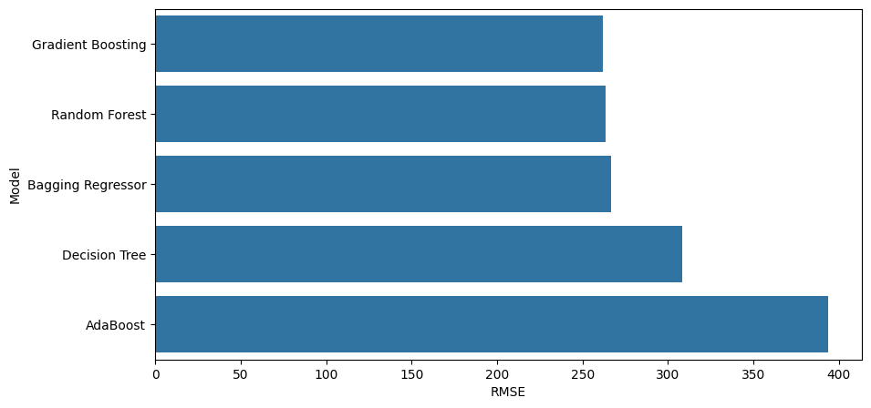

```python
# Visualization of model performance
import matplotlib.pyplot as plt
import seaborn as sns

plt.figure(figsize=(10, 5))
sns.barplot(x='RMSE', y='Model', data=performance_df)
```

# **Conclusion**

SuperKart may improve the accuracy of its sales forecasts and operational efficiency by implementing the important insights and recommendations that arose from a comprehensive analysis and model evaluation.

**Actionable Insights**:

Model performance was greatly enhanced by adding elements like store types, city levels, and product types. The accuracy of sales forecasts can be further improved by routinely updating and improving these features in response to shifting market conditions.

# **Recommendations**

**Adopt Gradient Boosting**:

Use the Gradient Boosting Regressor model to forecast sales on a regular basis. To keep the model accurate over time, make sure it is regularly retrained with fresh data. Extend Information Gathering:

Add more information on marketing, changes in the seasons, and economic statistics. This will increase forecasting accuracy and offer a more thorough understanding of the variables affecting sales. Optimization of the supply chain and inventory:

Utilize the sales forecast's insights to streamline inventory control. Precise forecasting can enhance supply chain efficiency by assisting in the maintenance of ideal stock levels, minimizing surplus inventory, and averting stockouts.

Strategic Sales Planning: Make use of the sales data forecasts to schedule regional operations and sales strategies. Based on anticipated high-performing areas and product categories, adjust marketing campaigns and sales initiatives. Constant observation and development:

Maintain a close eye on the forecasting model's performance and make sure feedback loops are included. Iteratively enhance the model by including fresh data and honing feature sets.

# **Final Thoughts**

**By leveraging advanced predictive models and continuously enhancing data inputs, SuperKart can achieve more accurate sales forecasts. This will enable better decision-making, optimized inventory management, and strategic sales planning, ultimately leading to increased operational efficiency and profitability.**